# 220405_limma_GBM

Jennifer Fisher

4/5/2022

# START

```
Goal/Purpose of operations:
Apply limma differential gene expression analysis to GBM and GTEx controls to identify genes that differential expressed between tumor and control gene expression profiles. The differential expressed gene were used to signature reversion.

Finished psedocode on:
220405

System which operations were done on:
my laptop

GitHub Repo:
Transfer_Learning_R03

Docker/Singularity:
rstudio_cancer_dr

Directory of operations:
"/home/rstudio"

Scripts being edited for operations:
using some modified scripts from MultiPLIER paper

Data being used:
TCGA GBM data and GTEx Brain samples

Papers and tools:
limma
MultiPLIER
```

# STEPS

### load in data

```r
library(recount3)
library(SummarizedExperiment)
library(dplyr)
library(signatureSearch)
library(signatureSearchData)
library(HDF5Array)
```

```r
library(magrittr)
library(dplyr)
library(recount3)
library(ggplot2)
 library(viridis)
library(tidyr)
library(ggpubr)
library(gprofiler2)
```

load in function scripts

```r
source("/home/rstudio/script/functions_cancer_signature_reversion_JLF.R")
source("/home/rstudio/script/plier_util.R")
source("/home/rstudio/script/test_LV_differences.R")
```

```r
all_metadata<- readRDS("~/data/recount3_GBM_GTEx_BRAIN_metadata.rds")
```

normalize count data by tpm

```r
feature_info <- readRDS("~/data/recount3/recount3_fix_download/feature_info.rds")
tpm_table<- readRDS("~/output/recount3_gbm_gtex_tpm_df.rds")
```

```r
tpm_df <- as.data.frame(tpm_table)
```

## limma analysis

transfrom TPM for limma differential gene expression

```r
TPM <- log2(as.matrix(tpm_df) + 1)
```

```r
#adjust metadata for the function
sampleinfo<- cbind(colnames(tpm_df), as.character(all_metadata$status), as.character(all_metadata$database))
colnames(sampleinfo) <- c("Sample", "Tumor","database")
sampleinfo<- as.data.frame(sampleinfo)
database<- all_metadata$database
names(database)<- colnames(tpm_df)
```

```r
limma_gene_TCGA_BH <- LVTestWrapperJLF_v2(b.matrix=TPM , sample.info.df= sampleinfo, phenotype.col= "Tumor", blocking= database, file.lead= "220421_limma_TCGA_GTEX_T_vs_NT", plot.dir= "~/output/limma_gbm/", results.dir= "~/output/limma_gbm/", use.bonferroni= FALSE, sig.threshold = 0.05)
```

```r
saveRDS(limma_gene_TCGA_BH , file= "~/output/limma_gbm/220421_GBM_GTEX_gene_limma_res.rds")
```

## signaturesearch

get the limma results

```r
GBM_GTEX_gene_limma_res <- readRDS("~/output/limma_gbm/220421_GBM_GTEX_gene_limma_res.rds")
```

get LINCS 2020 Level 5 data

```r
library(signatureSearch)
library(HDF5Array)
se <- SummarizedExperiment(HDF5Array("~/data/lincs_2020.h5", name="assay"))
```

```r
rownames(se) <- HDF5Array("~/data/lincs_2020.h5", name="rownames")
colnames(se) <- HDF5Array("~/data/lincs_2020.h5", name="colnames")
db_path <- "~/data/lincs_2020.h5"
```

```r
limma_results<- GBM_GTEX_gene_limma_res$limma
```

```r
limma_results<- limma_results[complete.cases(limma_results),]
limma_results_sig <- limma_results[limma_results$adj.P.Val < 0.05 & abs(limma_results$logFC) > 2,]
```

```r
upset<-limma_results_sig$LV[order(-limma_results_sig$logFC)]
downset<- limma_results_sig$LV[order(limma_results_sig$logFC)]
upset<- upset[1:200]
downset<- downset[1:200]
```

convert gene symbols to LINCS genes

```r
upset_v2 <- match_to_LINCS_genes(upset)
downset_v2 <- match_to_LINCS_genes(downset)
```

```r
downset_v2<- downset_v2[complete.cases(downset_v2)]
upset_v2<- upset_v2[complete.cases(upset_v2)]
```

```r
names(upset_v2)<- NULL
names(downset_v2)<- NULL
```

```r
limma_gbm_list<- list(up= upset_v2, down= downset_v2)
```

save the input gene signature.

```r
saveRDS(limma_gbm_list,"~/output/limma_gbm/SR_gene_list_gbm_limma.rds")
```

run signature reversion for limma GBM vs Control

```r
set.seed(101)
qsig_lincs_limma_res <- qSig(query=list(upset=as.character(upset_v2), downset=as.character(downset_v2)),
                   gess_method="LINCS", refdb=db_path)
```

```r
set.seed(101)
lincs_limma_gbm <- gess_lincs(qsig_lincs_limma_res, sortby="NCS", workers=1)
#result(lincs)
```

```r
lincs_limma_gbm_res <- result(lincs_limma_gbm)
```

```r
write.csv(lincs_limma_gbm_res , file= "~/output/limma_gbm/220421_SR_LINCS_GBM_LIMMA_RES.csv" )
```

tau calc

```r
lincs_limma_gbm_res_GI1 <- lincs_limma_gbm_res[lincs_limma_gbm_res$cell == "GI1",]
```

```r
GI1_taudf <- readRDS("~/data/GI1_taudf.rds")
```

```r
tau_test<- tau_scores(lincs_limma_gbm_res_GI1, GI1_taudf)
```

```r
lincs_limma_gbm_res_GI1$jlf_tau<-tau_test
```

```r
limma_sig_drugs <- lincs_limma_gbm_res_GI1[lincs_limma_gbm_res_GI1$WTCS_Pval <0.05 & lincs_limma_gbm_res_GI1$NCS <0 & as.numeric(lincs_limma_gbm_res_GI1$jlf_tau) < -80, ]
```

drug analysis

```r
#FDA_APPROVAL_CHECK
limma_sig_drugs$fda_database<- FDA_APPROVAL_CHECK(limma_sig_drugs$pert)
```

```r
limma_sig_drugs_fda <-limma_sig_drugs[ limma_sig_drugs$fda_database == TRUE,]
```

```r
FDA_CT_table<- read.csv("~/data/SearchResults.csv")
limma_sig_drugs_fda$GBM_CT<- clinical_trial_check(as.character(limma_sig_drugs_fda$pert), FDA_CT_table)
```

```r
limma_sig_drugs_fda_order <- limma_sig_drugs_fda[order(-limma_sig_drugs_fda$NCS),]
limma_sig_drugs_fda$pert <- factor(limma_sig_drugs_fda$pert, levels = limma_sig_drugs_fda_order$pert)
```

```r
p<-ggplot(data=limma_sig_drugs_fda , aes(x=pert, y=NCS, fill=jlf_tau, shape= GBM_CT)) +
  geom_bar(stat="identity", color= "black")+ scale_fill_viridis(direction=-1) + geom_point(aes(y = NCS - 0.15), position = position_dodge(0.9), size= 4, show.legend = TRUE)
p + coord_flip()  + ylab("Normalized Connectivity Score") + xlab("LINCS Small Molecules") +labs(fill = "Tau [-100,100]", shape= "Clinical Trials")
ggsave("~/output/limma_gbm/2200421_ggplot_limma_tau_gbm_approved_candidates.png")
```

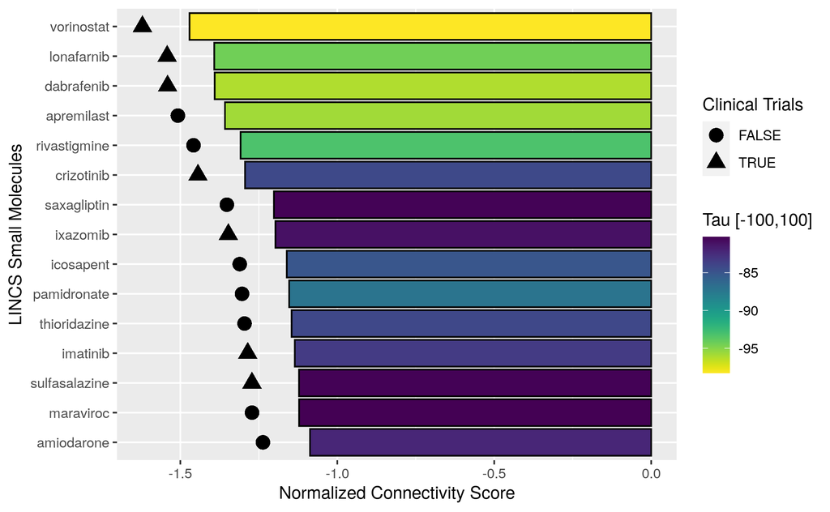

```r
knitr::include_graphics("~/output/limma_gbm/2200421_ggplot_limma_tau_gbm_approved_candidates.png")
```

```r
write.csv(limma_sig_drugs_fda , file = "~/output/limma_GBM/220808_SR_LINCS_GBM_top_RES_all.csv")
```

look at the brain tumor cell types

```r
lincs_limma_gbm_res_brain_tumor <- lincs_limma_gbm_res[lincs_limma_gbm_res$cell %in% c("GI1","SHSY5Y", "LN229","SKNSH", "U251MG","YH13")   ,]
```

```r
lincs_limma_gbm_res_brain_tumor_top  <- lincs_limma_gbm_res_brain_tumor[lincs_limma_gbm_res_brain_tumor$pert %in% limma_sig_drugs_fda$pert,]
```

```r
lincs_limma_gbm_res_brain_tumor_top$pert <- factor(lincs_limma_gbm_res_brain_tumor_top$pert, levels = unique(lincs_limma_gbm_res_brain_tumor_top$pert))
```

```r
g.2<-ggplot(data= lincs_limma_gbm_res_brain_tumor_top , aes(x=pert, y=NCS, color=cell)) +
  geom_point(stat="identity", size = 3)
g.2 + coord_flip() + scale_color_viridis_d()
```

[output not shown]

hard to get an idea if this drug response is common across brain tumor cell lines

PRISM plotting

```r
prism_gbm_cell_lines <- read.csv("~/output/220808_prism_gbm_candidates.csv")
```

```r
primary_gbm_res_sub <-prism_gbm_cell_lines[ prism_gbm_cell_lines$Var2 %in% limma_sig_drugs_fda$pert,]
write.csv(primary_gbm_res_sub , file= "~/output/limma_gbm/220808_prism_limma_candidates_gbm.csv" )
```

```r
#primary_paad_res_sub$Var2 <- factor(primary_paad_res_sub$Var2, levels=unique(primary_paad_res_sub$Var2))
primary_gbm_res_sub$Var2 <- factor(primary_gbm_res_sub$Var2, levels=unique(primary_gbm_res_sub$Var2[order(primary_gbm_res_sub$log_fold_change)]))
ggplot(primary_gbm_res_sub, aes(x=log_fold_change, y= Var2))+ geom_violin() + geom_point()+ geom_vline(xintercept = 0.3)  + ylab("Drug Candidates") + xlab("log fold change")
ggsave("~/output/limma_gbm/220808_ggplot_limma_candidates_prism_screen1.png")
```

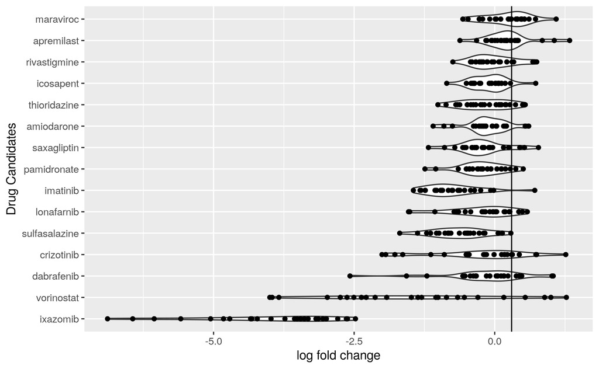

```r
knitr::include_graphics("~/output/limma_gbm/220808_ggplot_limma_candidates_prism_screen1.png")
```

look at the number of sensitive cell lines

```r
drug_list <- as.vector(unique(primary_gbm_res_sub$Var2))
drug_fraction<- c()
for (i in 1:length(drug_list)){
  cells <-primary_gbm_res_sub$Sensitive[primary_gbm_res_sub$Var2 %in% drug_list[i]]
  cells<- cells[!is.na(cells)]
  if( length(cells) < 12){
    print(drug_list[i])
  }
  #x<- table(cells)
  drug_fraction[i] <- length(cells[cells== TRUE])/ length(cells)
}
test <- ifelse(drug_fraction > 0.75, TRUE, FALSE)
drug_senstive_precentage_all_drugs <- data.frame(drug_fraction, drug_list, test)
drug_senstive_precentage_all_drugs$drug_list<- factor(drug_senstive_precentage_all_drugs$drug_list, levels= unique(drug_senstive_precentage_all_drugs$drug_list[order(drug_senstive_precentage_all_drugs$drug_fraction)]))
ggplot(drug_senstive_precentage_all_drugs, aes( drug_fraction, drug_list, fill= test ))+ geom_bar(stat="identity",  color= "black") + scale_fill_viridis_d() + ylab("Drug Candidates") + xlab("Fraction of Sensitive Cell Lines") +labs(fill = "75% of Cell line are Sensitive")
ggsave("~/output/limma_gbm/220808_ggplot_limma_candidates_prism_screen1_sensitive_cell_lines.png")
```

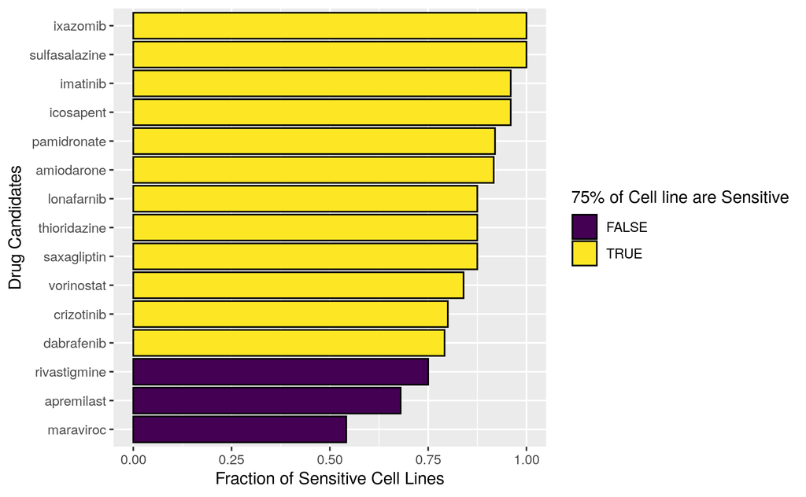

```r
knitr::include_graphics("~/output/limma_gbm/220808_ggplot_limma_candidates_prism_screen1_sensitive_cell_lines.png")
```

```r
limma_PRISM_test<- PRISM_testing(101,"GI1", limma_sig_drugs_fda$pert, drug_senstive_precentage_all_drugs)
```

```r
limma_PRISM_test
```

```
Wilcoxon signed rank test with continuity correction
```

data: fraction

V = 10392308, p-value < 2.2e-16

alternative hypothesis: true location is less than 0.875

determine if there are more drug from clinical trials than compared to random

```r
len<- length(limma_sig_drugs_fda$pert)
num_clin <- nrow(limma_sig_drugs_fda[limma_sig_drugs_fda$GBM_CT == TRUE,])
fract<- num_clin/len
limma_CT_test_res <- clinical_trial_testing(101, "GI1", len, fract, FDA_CT_table)
```

```r
limma_CT_test_res
```

```
Wilcoxon signed rank test with continuity correction
```

data: fraction_adj

V = 1900, p-value < 2.2e-16

alternative hypothesis: true location is less than 0.4666667

# END

```
Location of final scripts:
script

Location of data produced:
~/output/limma_gbm

Dates when operations were done:
2200421; updated 220802
```